# Survival analysis

Debora

2023-04-27

### Identifying surviving and non-surviving plants

Plants were considered as dead when they displayed >90% loss of green pigmentation at the end of the experiment (Thomson & Dennis, 2013).

The original result dataset for the autocorrelation experiment was modified so that each row (or each replicate) was repeated to correspond to the amount of living and dead individuals. Each non-surviving individual frond received a code of “0” (zero), and each surviving individual frond received a code of “1” (one). Each line below corresponds to a single individual frond.

```r
head(datin3[c(1,5,6,7,8,33)],5)
```

```
##   Experiment_Number Mean_temperature Treatment Incubator Species survival
## 1                81               37         0         2      LP        1
## 2                81               37         0         2      LP        1
## 3                81               37         0         2      LP        1
## 4                81               37         0         2      LP        1
## 5                81               37         0         2      LP        1
```

```r
tail(datin3[c(1,5,6,7,8,33)],5)
```

```
##      Experiment_Number Mean_temperature Treatment Incubator  Species survival
## 1433                98               37      0.95         3 Field_LM        0
## 1434                98               37      0.95         3 Field_LM        0
## 1435                98               37      0.95         3 Field_LM        0
## 1436                98               37      0.95         3 Field_LM        0
## 1437                98               37      0.95         3 Field_LM        0
```

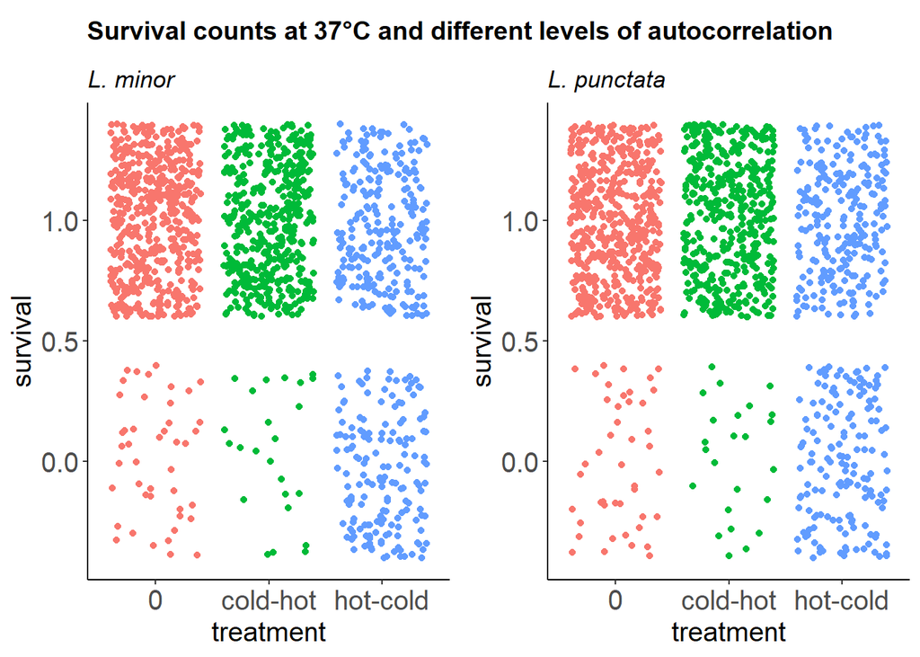

### Fitting a logistic model to the survival data:

|  | survival |  |  |
| --- | --- | --- | --- |
| Predictors | Odds Ratios | CI | p |
| (Intercept) | 12.95 | 8.53 – 20.82 | **<0.001** |
| label [cold-hot] | 4.81 | 1.80 – 16.65 | **0.004** |
| label [hot-cold] | 0.08 | 0.05 – 0.14 | **<0.001** |
| Species [LP] | 0.83 | 0.44 – 1.53 | 0.543 |
| label [cold-hot] * Species [LP] | 0.19 | 0.05 – 0.63 | **0.010** |
| label [hot-cold] * Species [LP] | 2.20 | 1.06 – 4.62 | **0.035** |
| Observations | 1437 |  |  |
| R<sup>2</sup> Tjur | 0.184 |  |  |

Both of the strong autocorrelation treatments are significantly different than the control (zero autocorrelation). The interaction effects between each of the treatments and the invasive species (LP) are also significant.

### Plotting estimates of the glm:

- the thick line (vertical intercept at position 1) indicates no effect
- horizontal lines are error bars
- numbers are estimates values
- asterisks are significance levels of p-values

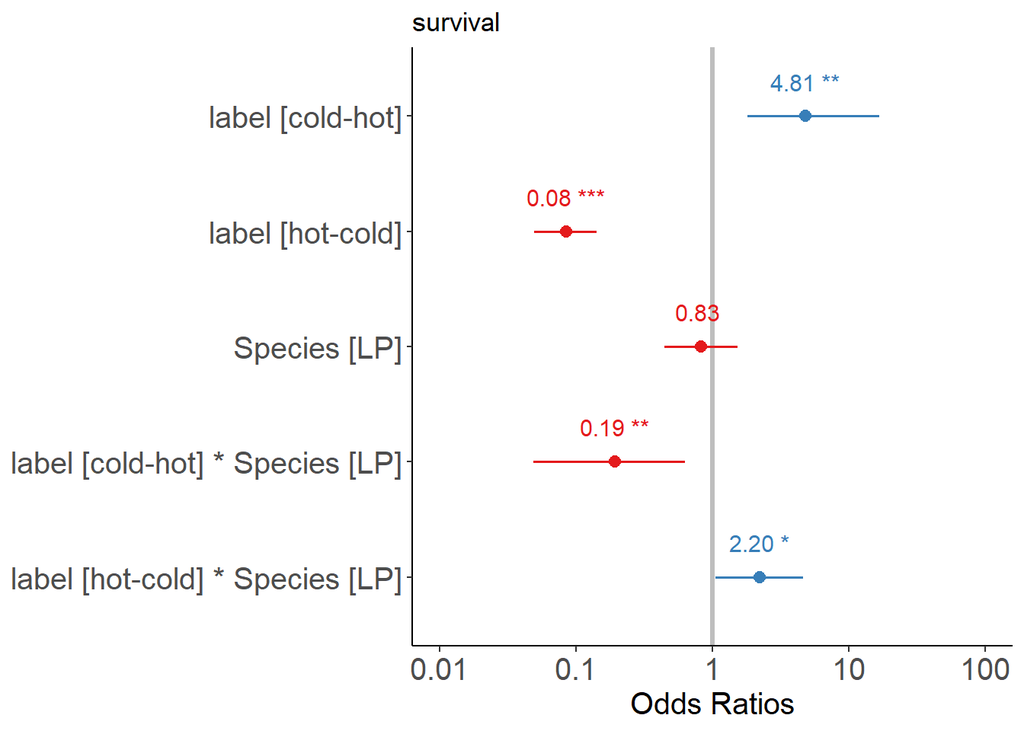

### Plotting model predictions (considering interactions terms):

- Vertical lines are error bars

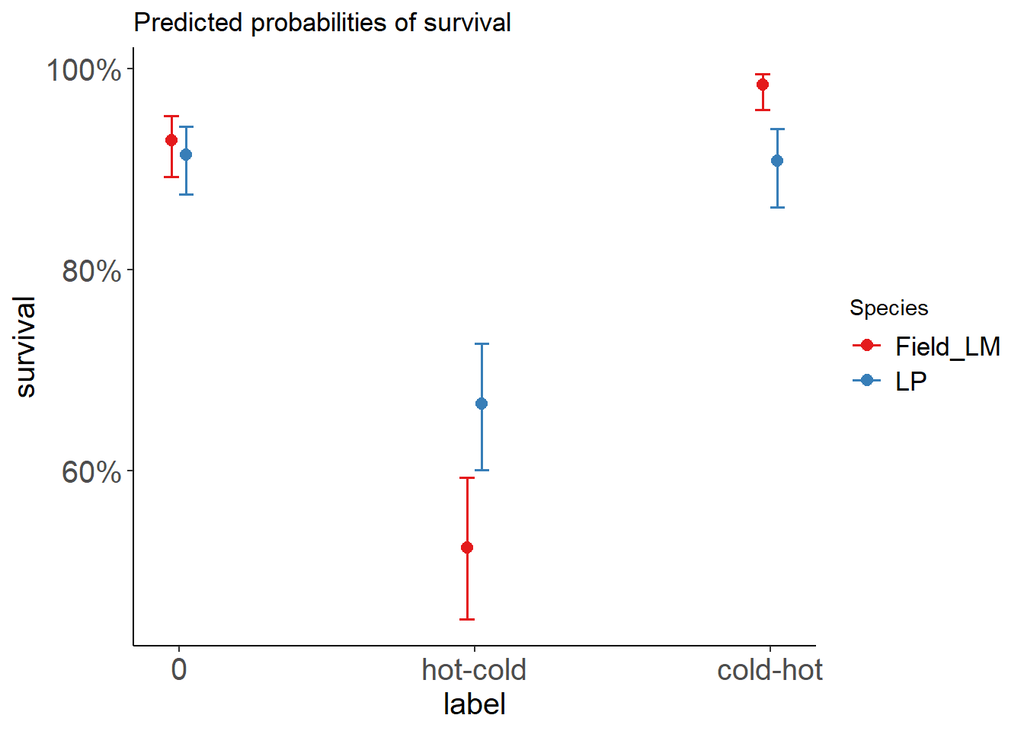

### Confusion matrix: determining model occurrence predictions based on threshold (eg., 60% survival); left diagonal is 91 and 1107 (correctly predicted values)

```
##              Predicted
## Actual        absence(0) presence(1)
##   absence(0)          91         100
##   presence(1)        139        1107
```

### Making a receiver operator curve (ROC) to analyze the model performance across several thresholds

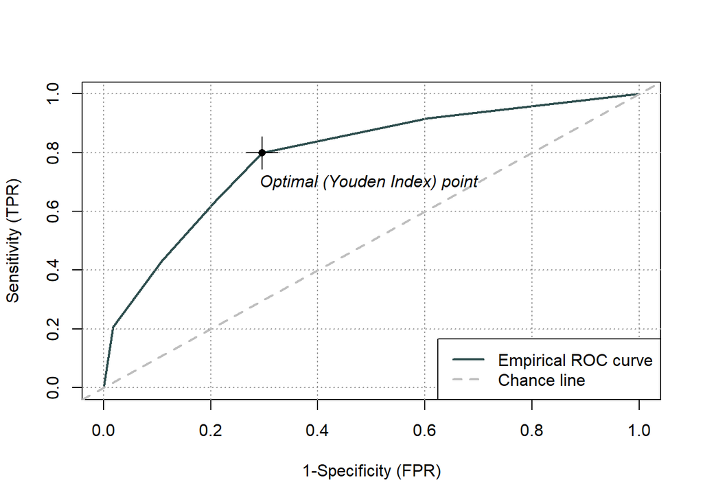

### Obtaining area under the curve (maximum is one)

```
##
##  Method used: empirical
##  Number of positive(s): 1207
##  Number of negative(s): 230
##  Area under curve: 0.7909
```

### Optimal threshold value given by the Youden index

```
##   threshold specificity sensitivity
## 1 0.7874618   0.7043478   0.7995029
```

### Post-hoc comparisons

```
## $`lsmeans of label, Species`
##  label    Species  lsmean    SE  df asymp.LCL asymp.UCL
##  0        Field_LM 2.5613 0.226 Inf     2.117     3.005
##  cold-hot Field_LM 4.1312 0.504 Inf     3.144     5.119
##  hot-cold Field_LM 0.0943 0.145 Inf    -0.190     0.378
##  0        LP       2.3698 0.218 Inf     1.942     2.797
##  cold-hot LP       2.2925 0.235 Inf     1.833     2.752
##  hot-cold LP       0.6931 0.145 Inf     0.408     0.978
##
## Results are given on the logit (not the response) scale.
## Confidence level used: 0.95
##
## $`pairwise differences of label, Species`
##  1                                         estimate    SE  df z.ratio p.value
##  0 Field_LM - (cold-hot Field_LM)           -1.5699 0.552 Inf  -2.842  0.0511
##  0 Field_LM - (hot-cold Field_LM)            2.4670 0.269 Inf   9.176  <.0001
##  0 Field_LM - 0 LP                           0.1914 0.314 Inf   0.609  0.9904
##  0 Field_LM - (cold-hot LP)                  0.2687 0.326 Inf   0.824  0.9632
##  0 Field_LM - (hot-cold LP)                  1.8681 0.269 Inf   6.942  <.0001
##  (cold-hot Field_LM) - (hot-cold Field_LM)   4.0368 0.524 Inf   7.700  <.0001
##  (cold-hot Field_LM) - 0 LP                  1.7613 0.549 Inf   3.208  0.0168
##  (cold-hot Field_LM) - (cold-hot LP)         1.8386 0.556 Inf   3.308  0.0121
##  (cold-hot Field_LM) - (hot-cold LP)         3.4380 0.524 Inf   6.556  <.0001
##  (hot-cold Field_LM) - 0 LP                 -2.2755 0.262 Inf  -8.692  <.0001
##  (hot-cold Field_LM) - (cold-hot LP)        -2.1982 0.276 Inf  -7.972  <.0001
##  (hot-cold Field_LM) - (hot-cold LP)        -0.5988 0.205 Inf  -2.918  0.0411
##  0 LP - (cold-hot LP)                        0.0773 0.320 Inf   0.241  0.9999
##  0 LP - (hot-cold LP)                        1.6767 0.262 Inf   6.398  <.0001
##  (cold-hot LP) - (hot-cold LP)               1.5994 0.276 Inf   5.795  <.0001
##
## Results are given on the log odds ratio (not the response) scale.
## P value adjustment: tukey method for comparing a family of 6 estimates
```

References:

- https://www.quantitative-biology.ca/
- (Thomson & Dennis, 2013): https://journals.plos.org/plosone/article?id=10.1371/journal.pone.0080102
- https://strengejacke.github.io/sjPlot/articles/plot_model_estimates.html#fitting-a-logistic-regression-model